# R Project

Group 4

20/11/2021

# Introduction

## Importance of Concrete

Concrete is of utmost importance in most types of construction as it provides **strength** to the underlying structure over a long period of time thereby showcasing its **durability** aspect. Now, in concrete, compressive strength is the property of great use because as a construction material, concrete is usually employed to resist compressive stresses. Even in situations when tensile stresses are predominant, compressive strength can be used to estimate those properties.

## Objective

We want to identify the dependency of concrete’s compressive strength on the concrete’s mixture, explore the degree of dependency through known parameters and formulate a suitable linear regression model

# Data Preparation

## Importing the libraries

```r
library(readxl)
library(ggplot2)
library(psych)
library(tidyverse)
library(crayon)
library(ggthemes)
library(ggpubr)
library(patchwork)
```

## Importing the data

Let’s have a glimpse of the data

```r
a = read_excel("Data.xls")
glimpse(a)
```

```
## Rows: 1,030
## Columns: 9
## $ `Cement (component 1)(kg in a m^3 mixture)`             <dbl> 540.0, 540.0, ~
## $ `Blast Furnace Slag (component 2)(kg in a m^3 mixture)` <dbl> 0.0, 0.0, 142.~
## $ `Fly Ash (component 3)(kg in a m^3 mixture)`            <dbl> 0, 0, 0, 0, 0,~
## $ `Water  (component 4)(kg in a m^3 mixture)`             <dbl> 162, 162, 228,~
## $ `Superplasticizer (component 5)(kg in a m^3 mixture)`   <dbl> 2.5, 2.5, 0.0,~
## $ `Coarse Aggregate  (component 6)(kg in a m^3 mixture)`  <dbl> 1040.0, 1055.0~
## $ `Fine Aggregate (component 7)(kg in a m^3 mixture)`     <dbl> 676.0, 676.0, ~
## $ `Age (day)`                                             <dbl> 28, 28, 270, 3~
## $ `Concrete compressive strength(MPa, megapascals)`       <dbl> 79.986111, 61.~
```

## Removing Duplicates

First we will check if our data contain duplicate rows of data and if it contains some then we will remove them as these data points do not conveying any new information to the model.

```r
dim(a[duplicated(a),])
```

```
## [1] 25  9
```

```r
a<-a%>%
  unique(fromLast=TRUE)
colnames(a) = c("cement","slag","ash","water","superplastic",
                "coarseAgg","fineAgg","age","strength")

a = as.data.frame(a)
```

# Data Exploration

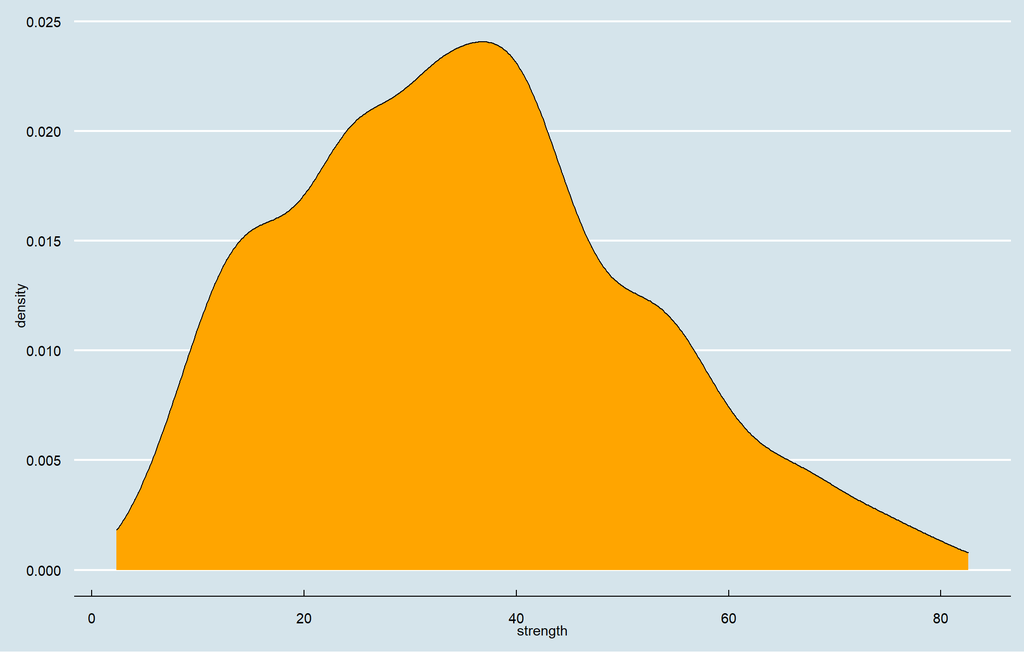

```r
ggplot(data=a,aes(x=strength),color='blue')+geom_density(
  aes(y=..density..),fill='orange')+theme_economist()
```

So, here we can see that our target variable is approximately normal distributed and it is a little skewed towards right.

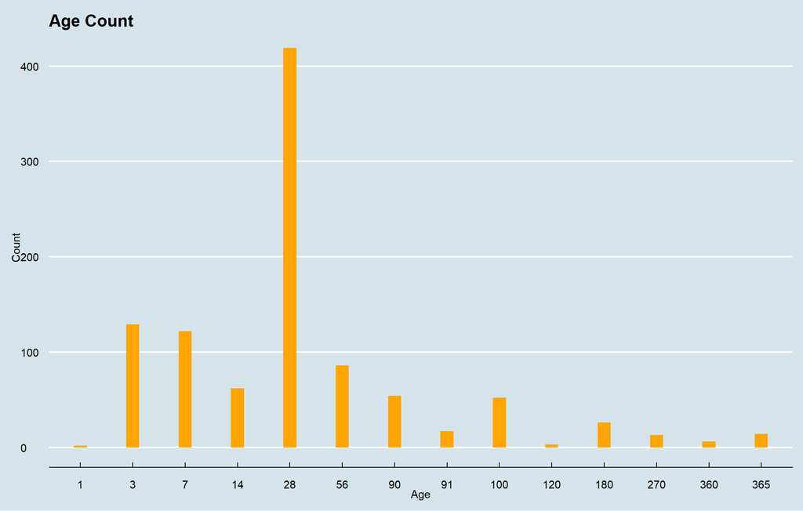

```r
p<-ggplot(data=a)
p+geom_bar(aes(x=as.factor(age)),width=0.25,fill='orange')+
  labs(x='Age',y='Count')+
  ggtitle("Age Count ")+
  theme_economist()
```

So, at first glance, age seems like a continuous variable but it is only taking certain number of values and the value “28” have ocurred more number of times.This may be due to the fact that the strength gained by concrete is maximum after 28 days and then it starts declining.

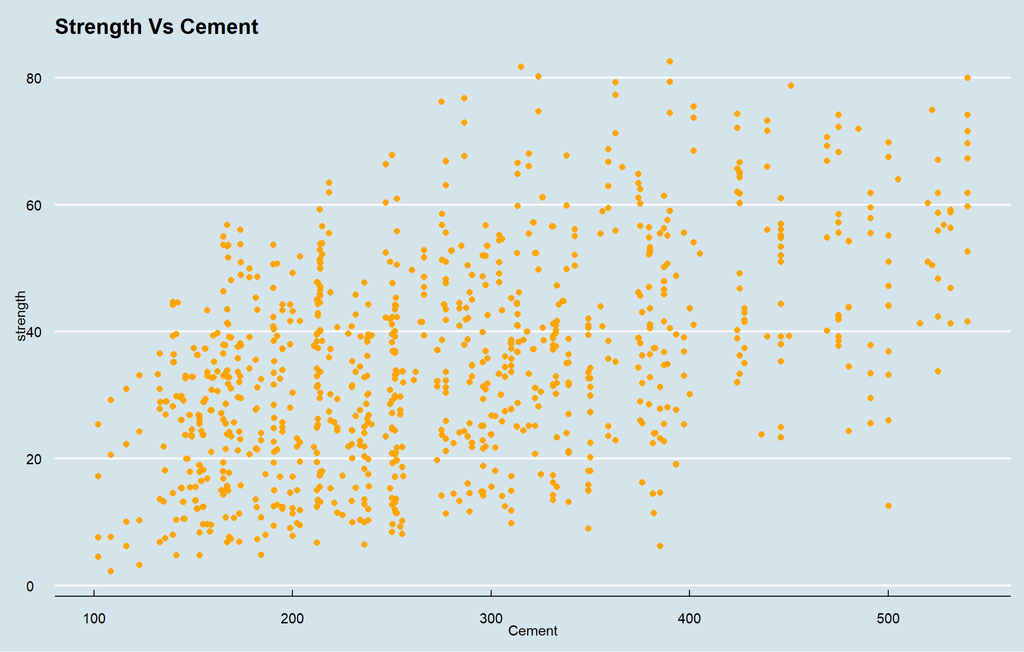

```r
p+geom_point(aes(x=cement,y=strength),size=2,color='orange')+
  labs(x="Cement",y="strength")+
  ggtitle("Strength Vs Cement ")+
  theme_economist()
```

From the above plot it is clear that cement is linearly related to concrete’s strength. So, it may be an important factor.

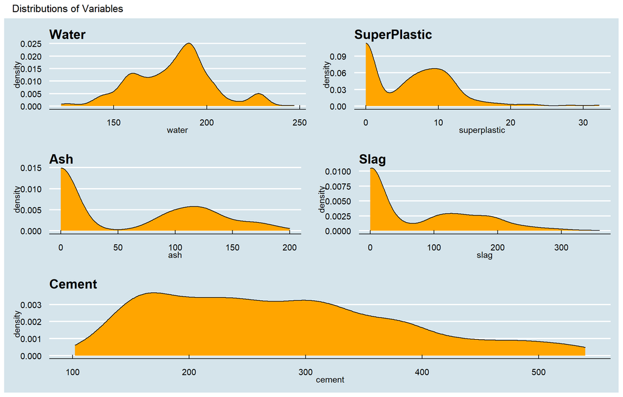

```r
p1<-p+geom_density(aes(x=water),fill='orange')+
  ggtitle("Water")+
  theme_economist()
p2<-p+geom_density(aes(x=superplastic),fill='orange')+
  ggtitle("SuperPlastic")+
  theme_economist()
p3<-p+geom_density(aes(x=ash),fill='orange')+
  ggtitle("Ash")+
  theme_economist()
p4<-p+geom_density(aes(x=slag),fill='orange')+
  ggtitle("Slag")+
  theme_economist()
p5<-p+geom_density(aes(x=cement),fill='orange')+
  ggtitle("Cement")+
  theme_economist()
(p1|p2)/
(p3|p4)/
  p5+
  plot_annotation(title="Distributions of Variables")
```

# Analysis

## Regression on all variables

We start with a linear regression model involving all the variables

```r
lr = lm(strength~.,a)
summary(lr)
```

```
##
## Call:
## lm(formula = strength ~ ., data = a)
##
## Residuals:
##     Min      1Q  Median      3Q     Max
## -28.139  -6.301   0.602   6.646  34.991
##
## Coefficients:
##                Estimate Std. Error t value Pr(>|t|)
## (Intercept)  -17.748084  26.419314  -0.672 0.501877
## cement         0.117221   0.008495  13.799  < 2e-16 ***
## slag           0.099445   0.010158   9.790  < 2e-16 ***
## ash            0.085632   0.012478   6.862 1.19e-11 ***
## water         -0.152630   0.039801  -3.835 0.000134 ***
## superplastic   0.283380   0.092929   3.049 0.002353 **
## coarseAgg      0.015621   0.009321   1.676 0.094092 .
## fineAgg        0.018291   0.010675   1.713 0.086940 .
## age            0.112181   0.005393  20.800  < 2e-16 ***
## ---
## Signif. codes:  0 '***' 0.001 '**' 0.01 '*' 0.05 '.' 0.1 ' ' 1
##
## Residual standard error: 10.29 on 996 degrees of freedom
## Multiple R-squared:  0.6038, Adjusted R-squared:  0.6006
## F-statistic: 189.8 on 8 and 996 DF,  p-value: < 2.2e-16
```

From the summary of the regression model, we see that the variables corresponding to columns `coarseAgg` and `fineAgg` are not statistically significant as their corresponding p value is more than 0.05, so they fail to reject the null hypothesis in the t test

## Removing the non-significant variables

```r
a2 = a[,-which(summary(lr)$coefficients[-1,4]>0.05)]
lr2 = lm(strength~.,a2)
summary(lr2)
```

```
##
## Call:
## lm(formula = strength ~ ., data = a2)
##
## Residuals:
##     Min      1Q  Median      3Q     Max
## -28.829  -6.519   0.555   6.603  35.207
##
## Coefficients:
##               Estimate Std. Error t value Pr(>|t|)
## (Intercept)  28.504229   4.170758   6.834 1.43e-11 ***
## cement        0.104254   0.004227  24.662  < 2e-16 ***
## slag          0.083801   0.004980  16.827  < 2e-16 ***
## ash           0.068410   0.007697   8.887  < 2e-16 ***
## water        -0.212540   0.020953 -10.144  < 2e-16 ***
## superplastic  0.240087   0.084439   2.843  0.00456 **
## age           0.111464   0.005369  20.759  < 2e-16 ***
## ---
## Signif. codes:  0 '***' 0.001 '**' 0.01 '*' 0.05 '.' 0.1 ' ' 1
##
## Residual standard error: 10.3 on 998 degrees of freedom
## Multiple R-squared:  0.6026, Adjusted R-squared:  0.6002
## F-statistic: 252.2 on 6 and 998 DF,  p-value: < 2.2e-16
```

## Descriptive statistics for identifying interaction and higher order terms

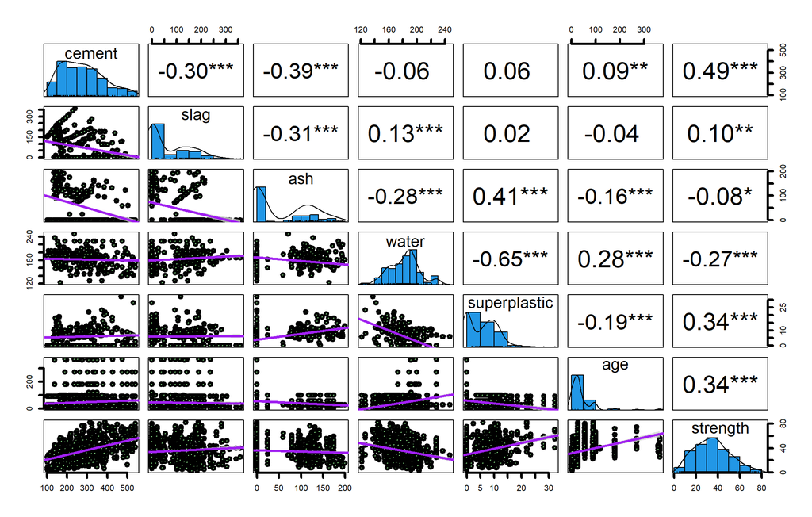

```r
pairs.panels(a2,
             smooth = FALSE,      # If TRUE, draws loess smooths
             scale = FALSE,      # If TRUE, scales the correlation text font
             density = TRUE,     # If TRUE, adds density plots and histograms
             ellipses = FALSE,    # If TRUE, draws ellipses
             method = "pearson", # Correlation method (also "spearman" or "kendall")
             pch = 21,           # pch symbol
             lm = TRUE,         # If TRUE, plots linear fit rather than the LOESS (smoothed) fit
             cor = TRUE,         # If TRUE, reports correlations
             jiggle = FALSE,     # If TRUE, data points are jittered
             factor = 2,         # Jittering factor
             hist.col = 4,       # Histograms color
             stars = TRUE,       # If TRUE, adds significance level with stars
             ci = TRUE, bg = c("light green"),col = "purple", lwd = 3)
```